# Trabajo Final - Bioestadística - Regresión Lineal Robusta

# **Trabajo Final - Bioestadística - Regresión lineal robusta**

El siguiente trabajo presenta un análisis de la cantidad de mesas con cero votos para los candidatos Milei y Massa respectivamente durante las elecciones generales de 2023. La fuente de los datos es un trabajo elaborado por el Centro de Investigación para la Calidad Democrática (CICaD) publicado en el sitio del centro [(link a la publicación)](https://cicad.ar/2023/10/31/el-recorrido-del-voto-en-las-elecciones-argentinas/?s=09). Se propondrá un análisis de regresión lineal bajo la teoría de los métodos robustos.

## **Análisis exploratorio de datos**

Se comienza cargando los datos y realizando un análisis exploratorio de datos.

El dataset a utilizar tiene 3 columnas:

1. **Provincia**: esta columna tiene el nombre de cada provincia argentina.
2. **Massa**: esta columna tiene la cantidad de mesas con cero votos al candidato Massa por provincia durante las elecciones generales de 2023.
3. **Milei**: esta columna tiene la cantidad de mesas con cero votos al candidato Milei por provincia durante las elecciones generales de 2023.

El dataset cuenta con 24 observaciones, una por cada provincia.

Se calculan medidas principales de cada columna.

|  | Max | Min | Media | Desvio_Estandar | NAs |
| --- | --- | --- | --- | --- | --- |
| Provincia | Tucumán | Buenos Aires | NA | NA | 0 |
| Massa | 708 | 3 | 68.8333333333333 | 141.616035282998 | 0 |
| Milei | 702 | 3 | 69.0833333333333 | 140.649090529113 | 0 |

Como primera observación puede notarse que en la base no hay datos faltantes. Adicionalmente los valores de media, desvío, máximos y mínimos de ambos candidatos son similares. Se procede a realizar un boxplot comparativo para ambos candidatos.

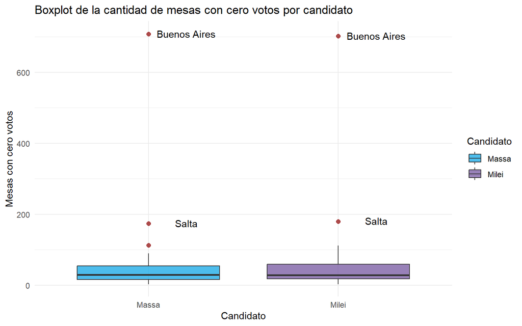

A continuación se realiza un qqplot más qqline para ambos candidatos.

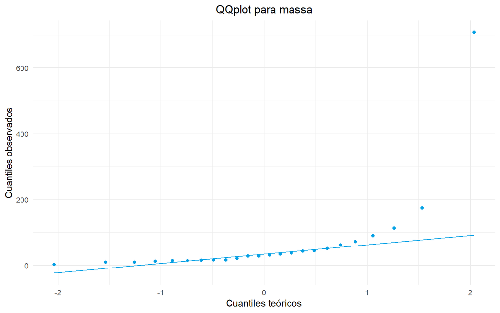

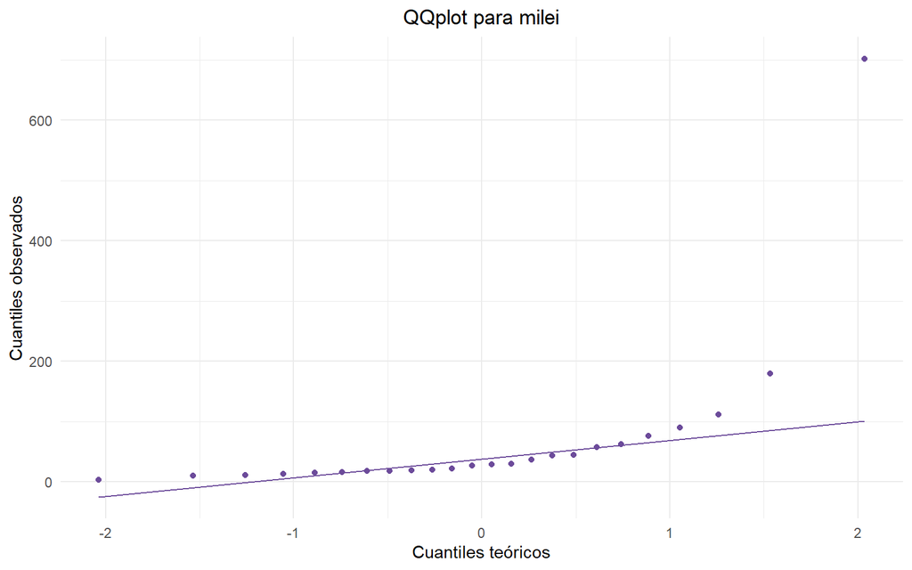

En ambos casos pareciera no tratarse de distribuciones normales. Se realiza un test de Shapiro-Wilk para cada variable. Para el caso del candidato Massa, el p-valor resulta aproximadamente 0. Para el candidato Milei, el p-valor también resulta aproximadamente 0. Con los p-valores obtenidos se encuentra evidencias suficientes para rechazar la hipótesis nula de que las variables provienen de una distribución normal.

Para analizar la interacción de ambas variables se presenta un scatterplot de ambas variables.

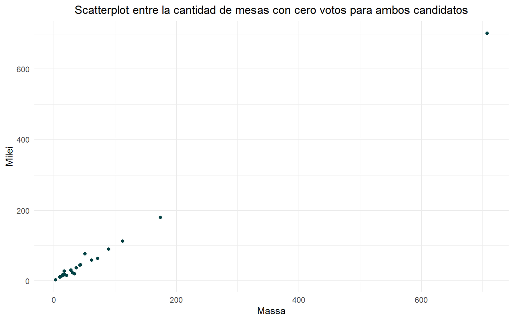

Del gráfico pueden extraerse dos conclusiones. Por un lado ambas variables parecieran tener una relación lineal. Por otro, se observan posibles puntos outliers e influyentes.

Para finalizar el análisis exploratorio se calcula un correlograma utilizando la distancia de Pearson entre ambas variables.

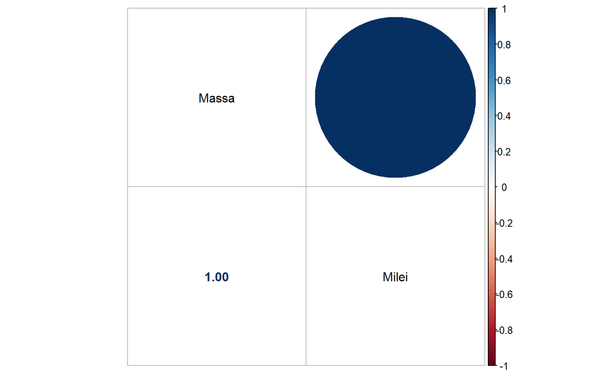

Puede notarse que la cantidad de mesas con cero votos para ambos candidatos parece estar altamente correlacionada de forma lineal. Se continúa con el análisis.

## **Modelo de regresión lineal por mínimos cuadrados ordinarios**

Para empezar a analizar la relación entre los datos se realiza una regresión lineal por mínimos cuadrados ordinarios (MCO). Se presentan los resultados obtenidos y la gráfica de la recta.

```
##
## Call:
## lm(formula = Milei ~ Massa, data = df)
##
## Residuals:
##     Min      1Q  Median      3Q     Max
## -14.534  -0.929  -0.293   1.350  24.605
##
## Coefficients:
##             Estimate Std. Error t value            Pr(>|t|)
## (Intercept)   0.8106     1.6873    0.48                0.64
## Massa         0.9919     0.0109   90.99 <0.0000000000000002 ***
## ---
## Signif. codes:  0 '***' 0.001 '**' 0.01 '*' 0.05 '.' 0.1 ' ' 1
##
## Residual standard error: 7.4 on 22 degrees of freedom
## Multiple R-squared:  0.997,  Adjusted R-squared:  0.997
## F-statistic: 8.28e+03 on 1 and 22 DF,  p-value: <0.0000000000000002
```

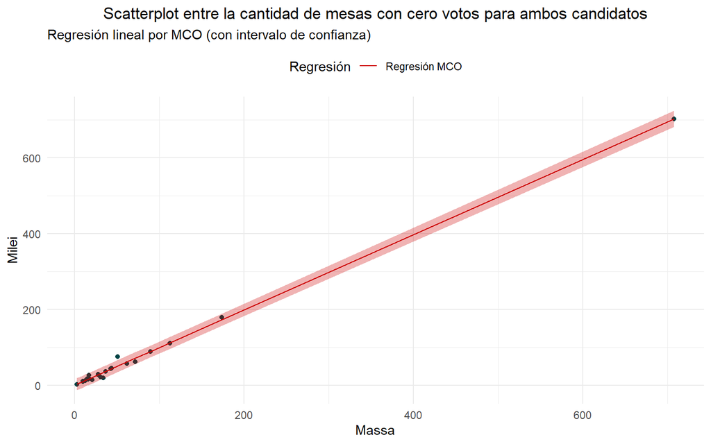

Como primer comentario, en el modelo obtenido se observa que que la pendiente resulta significativa con un valor cercano a 1, como era esperado. Por otro lado, la ordenada al origen no rechaza su test, con lo cual no se encuentra evidencia para rechazar que sea igual a cero. Finalmente. se obtiene un r cuadrado de 99.7%.

Se procede a analizar los supuestos del test comenzando por la normalidad de los resiudos. En primer lugar se construye un qqplot con los residuos del modelo.

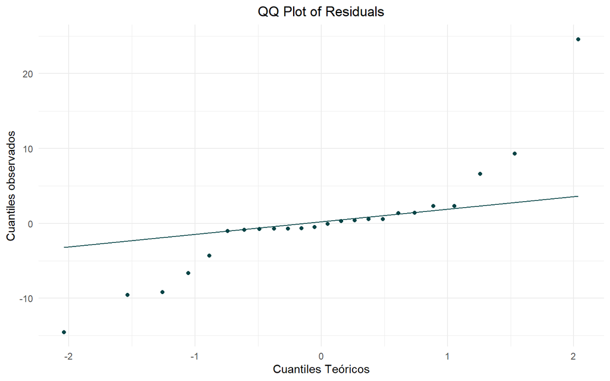

En el gráfico pareciera observarse una falta de normalidad en los residuos. Se va a confirmar esto realizando un test de Shapiro-Wilk sobre los mismos. El test arroja un p-valor de 0.0008. Con este resultado se encuentran evidencias estadísticas suficientes para rechazar la hipótesis nula de que los residuos provienen de una distribución normal.

## **Análisis de valores atípicos (outliers)**

Ya al violarse el supuesto de normalidad de los residuos el modelo resulta inadecuado. Antes de proponer una solución se realiza un análisis de valores atípicos. Para esto se comienzan calculando las medidas de influencia vistas en clase.

```
## Potentially influential observations of
##   lm(formula = Milei ~ Massa, data = df) :
##
##    dfb.1_ dfb.Mass dffit   cov.r   cook.d  hat
## 2   0.45  -1.80_*  -1.84_* 14.73_*  1.75_*  0.93_*
## 22  0.96  -0.13     1.01_*  0.26_*  0.26    0.04
```

Puede observarse que se identifican dos potenciales outliers: las observaciones 2 y 22 (Buenos Aires y Santiago del Estero, respectivamente). Se realiza un análisis de cada medida.

- El **DFBETA** de Massa (*dfb.Mass*) muestra que el punto 2, Buenos Aires, está afectando significativamente la pendiente de la regresión. Se observa que su presencia está generando un valor menor de pendiente.
- El **DFFIT** (*dffit*) muestra cómo varían las predicciones quitando cada punto. Notar que tanto para el punto 2 como para el punto 22 se observan valores signficativos.
- La **Razón de covariancias** (cov.r) muestra cómo cambia la matriz de covariancias si se excluye una observación. Ambos puntos tienen valores alejados de 1, lo cual podría indicar que son valores influentes.
- La **Distancia de Cook** (cook.d) tiene una interpretación similar al DFFIT. En este caso arroja un valor muy alto para Buenos Aires.
- Finalmente, **hat** muestra la distancia de la observación al centroide de los valores de la variable independiente. En este caso también los valores más altos se encuentran en Buenos Aires.

Se presentan gráficamente los datos a fin de identificar los dos puntos considerados candidatos a ser influyentes.

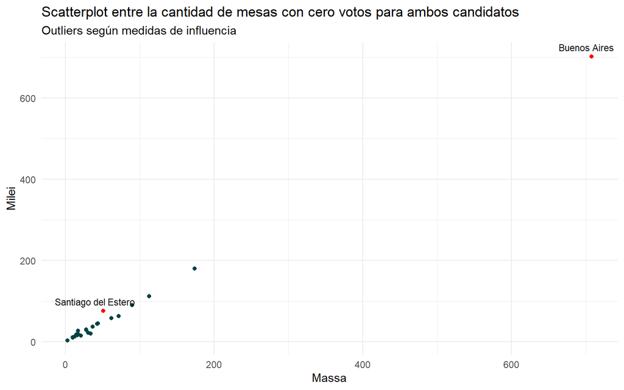

A simple vista no pareciera que estos puntos sean influyentes, aunque sí podrían ser outliers. De todas formas, tomando el criterio de las medidas de influencia, se consideran potenciales puntos influyentes.

Se propone a su vez otra metodología para analizar outliers. La misma está propuesta en el paper “Unmasking Multivariate Outliers and Leverage Points” de Rousseeuw y Zomeren. Se definen tres tipos de valores outliers dentro de una regresión. Por un lado se encuentran los *Good Leverage Points* que representan valores atípicos en **x** pero no en **y**. Por otro lado están los *Vertical Outliers* que son valores atípicos en **y** pero no en **x**. Estos dos tipos de outliers no tienen una gran influencia en los valores de los parámetros. Finalmente están los *Bad Leverage Points* que son valores atípicos en **x** e **y**. Estos sí representan un problema para los parámetros de la regresión. A fin de identificarlos se utiliza un método gráfico que presenta los valores de los residuos estandarizados de la regresión (utiliza el método de Least Trimmed Squares) y las distancias robustas de las observaciones al centroide de los datos. El gráfico se divide en 6 rectángulos que indican lo siguiente:

$$\begin{array}{|c|c|}
\hline
Vertical\ Outliers & Bad\ Leverage\ Points \\
\hline
Puntos\ normales & Good\ Leverage\ Points \\
\hline
Vertical\ Outliers & Bad\ Leverage\ Points \\
\hline
\end{array}$$

Se procede a calcular el gráfico.

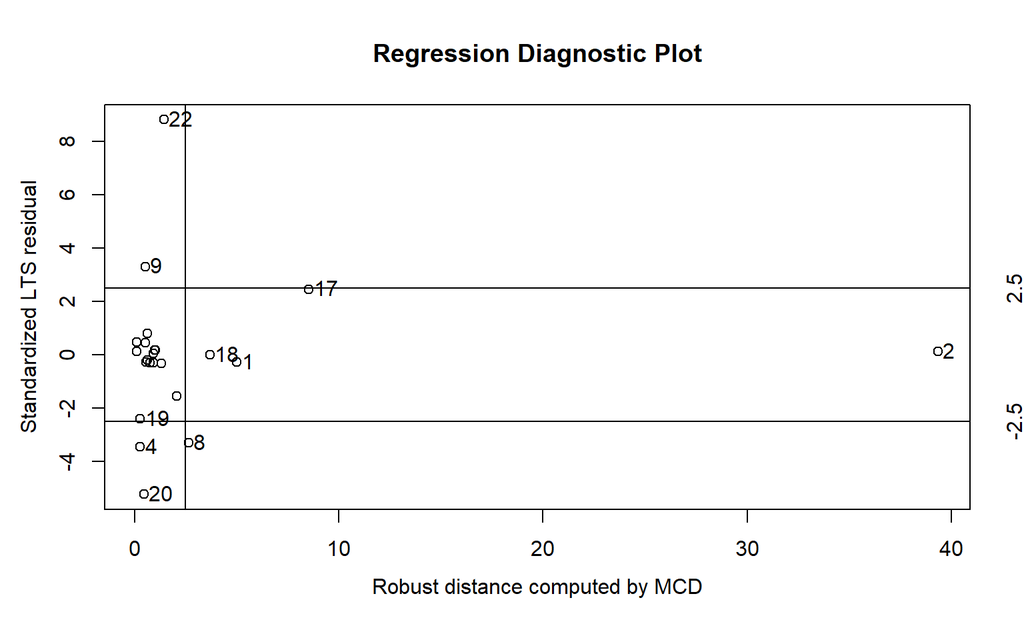

Este método sugiere lo siguiente:

- CABA, Buenos Aires, Salta y San Juan (1, 2, 17 y 18) son outliers en **x** no influyentes ( *Good Leverage Points*). Salta estaría en el límite entre Good y Bad Leverage Point.
- Córdoba, Formosa, Santa Cruz y Santiago del Estero (4, 9, 20 y 22) serían outliers en **y** no influyentes ( *Vertical Outliers*).
- Entre Ríos (8) sería un outlier influyente (*Bad Leverage Points*). De todos modos, notar que se encuentra casi en el límite con los *Vertical Outliers*.

Veamos esto en un scatterplot.

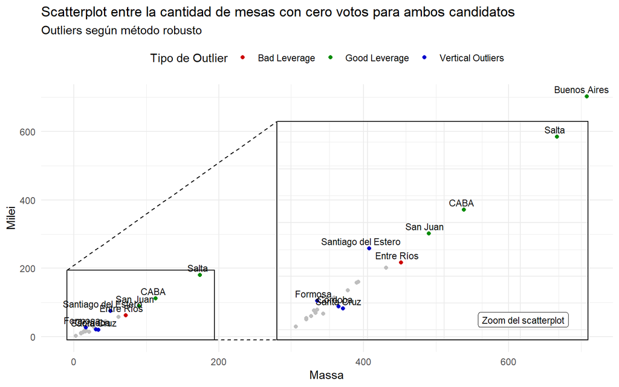

Observar cómo los *Good Leverage Points* (en verde) se posicionan casi en linea desde el origen. Por otro lado, los *Vertical Outliers* (en azul) oscilan cerca de la linea mencionada. Finalmente, el *Bad Leverage Point* (en rojo, Entre Ríos) parece ser más un *Vertical Outlier* que un outlier influyente.

A fin de solucionar esto se propone el cálculo de una regresión lineal por métodos robustos.

## **Modelo de regresión lineal por métodos robustos**

En esencia, lo que se busca utilizando estimadores robustos es minimizar la influencia de los valores outliers influyentes. Se utilizarán estimadores MM ya que los outliers se presentan tanto en el rango de la variable predictora como de la predicha. El procedimiento consiste en estimar los parámetros de la regresión minimizando la función de pérdida de los residuos mediante una función particular. En este caso se utiliza la función Bisquare. A los residuos se le asignan pesos que minimizan la influencia de los valores outliers. Este proceso se realiza de forma iterativa hasta alcanzar la convergencia.

Se procede a ajustar un modelo de regresión lineal utilizando estimadores MM. Se presentan los resultados comparados de ambas regresiones.

| Metodologia | Beta_Massa | P_Valor_Massa | R2 |
| --- | --- | --- | --- |
| MCO | 0.992 | 0 | 0.997 |
| MM Robusto | 0.991 | 0 | 1.000 |

Notar que ambas regresiones arrojan valores muy similares. Veamos cómo se ve esto gráficamente. Primero graficamos las regresiones sin intervalos de confianza de las predicciones.

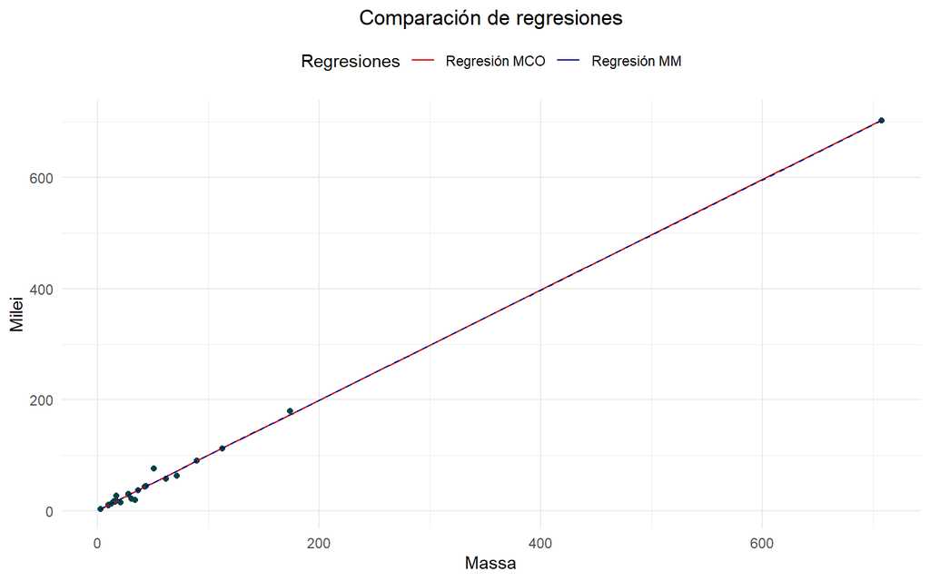

Notar que en este caso las rectas son casi idénticas. Veamos qué sucede al agregar los intervalos de confianza de las predicciones.

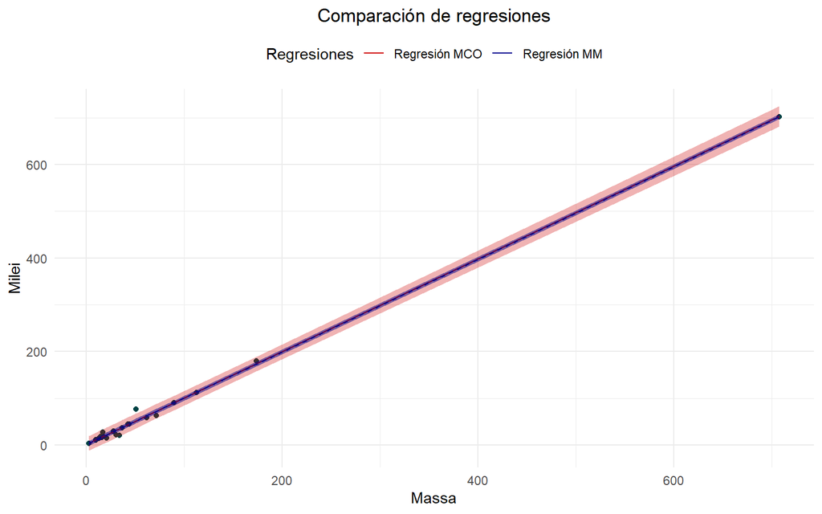

Puede observarse cómo la regresión robusta al compensar el efecto de los valores outliers genera intervalos de confianza considerablemente más pequeños.

Se procede a calcular los intervalos de confianza para los betas de ambas regresiones.

| regresion | beta | lim_inf | lim_sup | amplitud_intervalo |
| --- | --- | --- | --- | --- |
| MCO | Ordenada | -2.6886 | 4.3099 | 6.9984 |
| MM | Ordenada | -0.6228 | 2.3304 | 2.9532 |
| MCO | Pendiente | 0.9692 | 1.0145 | 0.0452 |
| MM | Pendiente | 0.9876 | 0.9938 | 0.0062 |

En la tabla puede observase cómo las estimaciones de los betas presentan una variancia menor frente a la presencia de outliers cuando se trabaja con el método de regresión robusta.

Para finalizar vamos a ajustar un modelo de regresión por MCO pero utilizando los pesos asignados en nuestra regresión robusta. Veamos los pesos asignados.

```
##       1       2       3       4       5       6       7       8       9      10
## 0.98980 0.99886 0.99511 0.07510 0.91882 0.96885 0.99909 0.10941 0.09806 0.99738
##      11      12      13      14      15      16      17      18      19      20
## 0.99213 0.99084 0.99588 0.91882 0.99149 0.97319 0.40566 1.00000 0.42021 0.00000
##      21      22      23      24
## 0.73078 0.00000 0.99527 0.98920
```

Notar que existen 2 observaciones a las que está dando un peso de cero: la 20 y la 22 (Santa Cruz y Santiago del Estero). Esto quiere decir que el estimador elegido interpreta que esos dos valores están influyendo en los resultados de la regresión. Veamoslos gráficamente.

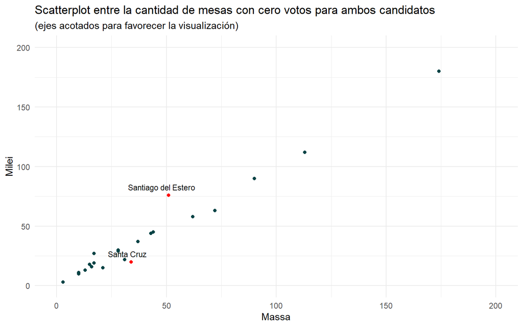

Esto pareciera indicar que Santa Cruz y Santiago del Estero son influyentes en la regresión. Podría considerarse una tercera forma de analizar valores atípicos, sumándose a los dos métodos vistos anteriormente.

Finalmente, a modo expositivo, se realiza el ajuste de regresión lineal por MCO pero introduciendo los pesos calculados mediante el método robusto.

| Metodologia | Beta_Massa | P_Valor_Massa | R2 |
| --- | --- | --- | --- |
| MCO | 0.992 | 0 | 0.997 |
| MM Robusto | 0.991 | 0 | 1.000 |
| MCO Ponderado | 0.991 | 0 | 1.000 |

Notar que efectivamente, el MCO ponderado arroja los mismos resultados que la regresión por métodos robustos.

## **Conclusiones finales**

A modo de conclusión, tras ajustar un modelo de métodos robustos a los datos de cantidad de mesas con cero votos por provincia durante las elecciones generales del 2023 se puede concluir que existe una relación lineal entre la cantidad de mesas con cero votos de Massa y de Milei. El beta de la regresión es aproximadamente uno. La ordenada al origen es cero. Es decir, el aumento en una unidad de la cantidad de mesas con cero votos para Massa equivale a un aumento de igual magnitud para el candidato Milei y la recta pasa por el origen. Adicionalmente, el R2 es practicamente igual a 1. Por ende, la variabilidad de la cantidad de mesas con cero votos para Milei se explican en un 100% por la variabilidad en la cantidad de mesas con cero votos para Massa. Con esto pareciera que la cantidad de mesas con cero votos es aproximadamente la misma en todas las provincias para ambos candidatos.

Sobre la metodología aplicada cabe mencionar algunos aspectos. Por un lado, a juzgar por la poca diferencia entre los parámetros de ambas regresiones, los valores atípicos encontrados resultaron ser todos no influyentes. El motivo principal para utilizar una regresión robusta en este caso es el no cumplimiento del supuesto de normalidad de los residuos para la regresión calculada por MCO. Además, la regresión robusta produjo intervalos de confianza más acotados tanto para las predicciones del modelo como para los betas.

Con esto concluye el trabajo.